# ViewCastLK: simple EDA of every input

What does each input tell us about how many views a Sri Lankan YouTube video gets? One input at a time, with plain charts and a short explanation under each.

Dataset build: **18 September 2026**. The interpretation text was written against that build; every number in a chart or table is recomputed when the notebook runs.

## How to read the charts

Each input gets the same two charts.

- **Left: how common each value is.** Number of videos with that value.
- **Right: day-7 views for each value, as "× typical".**
  - **Blue dot:** the typical (median) video with that value, compared with the typical video overall. **1×** is average, **2×** is twice the views, **0.5×** is half. The axis is a log scale, so 2× and 0.5× are the same distance from 1×.
  - **Blue band:** where the middle half of those videos fall. A tall band means videos with that value vary a lot.
  - **Orange diamond: compared with its own channel.** Each video's views divided by its channel's average views (on the log scale), averaged over the group. This removes channel size. Only channels that post videos with more than one value of the input are counted (a channel that only posts Shorts cannot tell us whether Shorts beat long-form), and a diamond needs at least 5 such channels. If the blue dot is high but the orange diamond is near 1×, the value only looks good because big channels use it.

A table under each chart gives the actual numbers, followed by a summary.

## Why the orange diamond matters

Channel size explains far more of the views than anything else. So a raw comparison ("Comedy gets more views than News") is often really a comparison of which channels post it. The orange diamond answers the question a creator actually has: **for my channel, does this help?**

Some inputs are the same for almost every video of a channel (subscribers, category, topic), so there is no within-channel comparison to make. Those are judged on the raw view only.

## The keep or drop rule

- **Drop** if 95% or more of videos have the same value.
- **Inputs fixed per channel** (channel statistics, category, topic): **keep** if the input explains at least **1%** of the variation in day-7 views.
- **Inputs that vary within a channel** (everything else): **keep** if, compared with their own channel, the best value's videos get at least **1.2×** the worst value's (groups of at least 200 videos). Because some inputs matter for small channels and not big ones, an input also passes if it reaches 1.2× inside one channel-size band, as long as every group there comes from at least 20 channels.
- "Explains %" is the share of the variation in log day-7 views that the input's groups account for on their own. 0% means views look the same in every group.

## Which videos

Live streams and videos without a duration are left out. Each horizon (7, 14, 21, 30 days) uses only videos with a label at that horizon. The per-input charts use **day 7**, which has the most videos. Where the notebook compares horizons, it uses the same videos (those with all four labels) so that time is the only difference.

# 1. Data overview

|  | value |
| --- | --- |
| rows in the file | 123,766 |
| live streams (left out) | 2,829 |
| no duration, unavailable (left out) | 1,522 |
| videos analysed | 119,415 |
| channels | 2,555 |
| published | 02 Jul 2026 to 18 Sep 2026 |
| videos with a day-7 label | 77,399 |
| videos with a day-14 label | 73,057 |
| videos with a day-21 label | 72,704 |
| videos with a day-30 label | 73,678 |
| videos with all four labels | 43,765 |

**What this shows.** About 124,000 videos from roughly 2,500 Sri Lankan channels, published from 2 July to 18 September 2026. Around 4,000 are left out (live streams, and videos that had no duration because they were removed). Each horizon has about 73,000 to 77,000 labelled videos, and about 44,000 videos have all four labels.

## Data dictionary

Every column in the file, grouped by what it is. **Inputs** are what the model may use. **Labels** are what it predicts. **Bookkeeping** columns describe how the row was built and are never inputs.

| column(s) | type | meaning |
| --- | --- | --- |
| video_id, channel_id | id | identifiers |
| published_at | input (timing) | publishing time, UTC; hour, weekday and weeken... |
| title, tags, thumbnail_url | raw text | title and tag features are worked out from these |
| category_id, category_name | input (format) | YouTube category |
| duration_seconds | input (format) | video length |
| is_short | input (format) | real Short: vertical or square and at most 3 m... |
| is_short_source, is_vertical | bookkeeping | whether the player shape or the old 60 s rule ... |
| definition, caption, made_for_kids | input (format) | HD or SD, captions, made-for-kids setting |
| default_audio_language, default_language | input (language) | spoken language, and title/description language |
| publish_hour_slt, publish_dow_slt, publish_is_weekend | input (timing) | Sri Lanka time |
| publish_hour_sin/cos, publish_dow_sin/cos | input (timing) | the same hour and weekday as points on a circl... |
| title_length ... title_script | input (title) | length, word count, number, ?, !, capitals, wr... |
| description_length, tag_count | input (text) | description size and number of tags |
| ch_subs/views/videos_at_publish, channel_age_days_at_publish | input (channel) | the channel on the day the video was published |
| channel_country, topic_categories | input (channel) | channel country and the channel's YouTube topics |
| dN_views | label | views N days after publishing (N = 7, 14, 21, 30) |
| dN_likes, dN_comments | outcome, never an input | happen after publishing, so using them would l... |
| dN_hours_off, dN_usable | bookkeeping | how far the observation was from exactly N day... |
| eligible, is_live_broadcast | bookkeeping | rows left out of analysis |
| channel_stats_backfilled, ch_stats_as_of | bookkeeping | channel statistics recorded only after publishing |
| title_changed, description_changed | bookkeeping | edited since first seen |

## Types and missing values of the input columns

|  | type | missing or blank | distinct values | example |
| --- | --- | --- | --- | --- |
| category_name | str | 0.8% | 14 | Entertainment |
| duration_seconds | float64 | 0.0% | 7,007 | 3157.0 |
| is_short | bool | 0.0% | 2 | False |
| definition | str | 0.0% | 2 | hd |
| caption | str | 0.0% | 2 | false |
| made_for_kids | object | 0.0% | 2 | False |
| default_audio_language | str | 7.6% | 38 | si |
| default_language | str | 0.0% | 44 | si |
| publish_hour_slt | int32 | 0.0% | 24 | 8 |
| publish_dow_slt | int32 | 0.0% | 7 | 3 |
| publish_is_weekend | bool | 0.0% | 2 | False |
| title_length | int64 | 0.0% | 100 | 27 |
| title_word_count | int64 | 0.0% | 23 | 5 |
| title_has_number | bool | 0.0% | 2 | False |
| title_has_question | bool | 0.0% | 2 | False |
| title_has_exclaim | bool | 0.0% | 2 | False |
| title_upper_ratio | float64 | 0.0% | 1,709 | 0.0 |
| title_script | str | 0.0% | 4 | sinhala_script |
| description_length | int64 | 0.0% | 3,917 | 422 |
| tag_count | int64 | 0.0% | 63 | 4 |
| ch_subs_at_publish | float64 | 0.0% | 3,456 | 1140000.0 |
| ch_views_at_publish | float64 | 0.0% | 32,470 | 366171655.0 |
| ch_videos_at_publish | float64 | 0.0% | 6,766 | 12399.0 |
| channel_age_days_at_publish | float64 | 0.0% | 119,343 | 3523.9313541666666 |
| channel_country | str | 0.0% | 3 | LK |
| topic_categories | str | 0.6% | 524 | https://en.wikipedia.org/wiki/Television |

**What this shows.** Almost every input is complete. The exceptions are audio language (not set on about 8% of videos) and category (under 1%). Channel statistics look complete here, but for about 31% of videos they were recorded only after publishing (see section 2), so the channel charts leave those out.

## Videos published per day

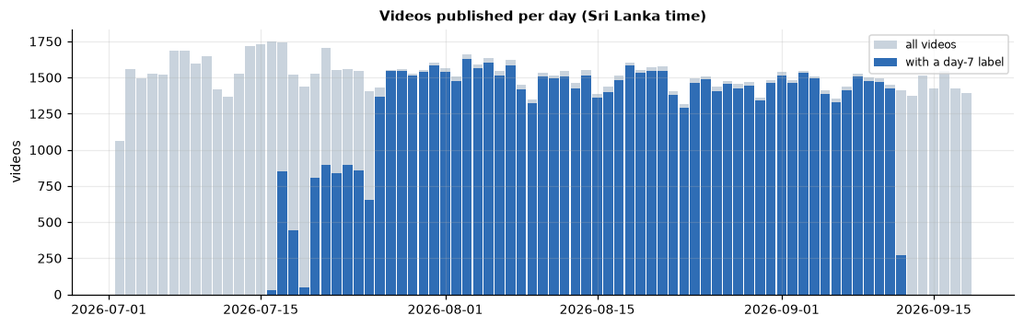

**What this shows.** About 1,400 to 1,700 videos are published per day, steady across the whole period. Videos from the first two weeks mostly have no day-7 label because tracking had not started for them yet. The last week has no day-7 label yet because those videos are not 7 days old.

# 2. Data quality

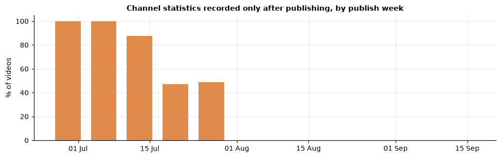

| horizon | labels | median distance from exact day | within 3 h | within 12 h |
| --- | --- | --- | --- | --- |
| day 7 | 77,399 | 1.5 h | 93% | 100% |
| day 14 | 73,057 | 1.5 h | 92% | 100% |
| day 21 | 72,704 | 1.5 h | 92% | 100% |
| day 30 | 73,678 | 1.5 h | 92% | 100% |

|  | share of videos |
| --- | --- |
| channel stats recorded after publishing | 30.9% |
| title edited after first seen | 1.2% |
| description edited after first seen | 1.6% |
| Short flag decided by player shape | 97.9% |

**What this shows.**

- **Channel statistics recorded after publishing** (31% of videos) are all from videos published before 1 August: every video in the first two weeks, 87% in the third and about half in the next two. None after that. For those videos we do not know the channel's size on publishing day, so channel charts leave them out rather than guess.
- **Labels are close to the exact day.** The typical label is 1.5 hours away from exactly 7, 14, 21 or 30 days, over 90% are within 3 hours, and none is more than 12 hours away.
- **Titles and descriptions are rarely edited** (about 1 to 2%), so the title we recorded is almost always the one the video was published with.
- **The Short flag** comes from the video's player shape for 98% of videos.

# 3. The target: views at 7, 14, 21 and 30 days

| horizon | videos | median | 25th pct | 75th pct | 90th pct | 99th pct | largest | share with 0 views |
| --- | --- | --- | --- | --- | --- | --- | --- | --- |
| day 7 | 77,399 | 1.2K | 210 | 6.1K | 31.8K | 340.3K | 17.4M | 0.7% |
| day 14 | 73,057 | 1.2K | 210 | 5.9K | 31.8K | 354.4K | 46.3M | 0.6% |
| day 21 | 72,704 | 1.1K | 199 | 5.7K | 31.1K | 356.5K | 56.7M | 0.5% |
| day 30 | 73,678 | 1.1K | 205 | 5.8K | 31.8K | 375.4K | 58.3M | 0.4% |

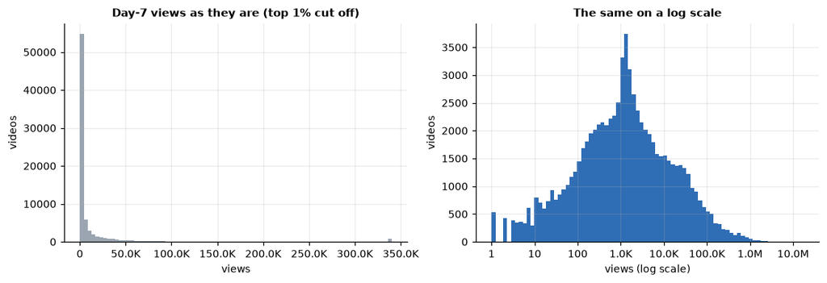

**What this shows.** Views are extremely uneven. The typical video gets about 1,200 views in its first week, a quarter get under about 200, and the top 1% get over 340,000. On a normal scale (left) almost every video is squashed against zero. On a log scale (right) the shape is easy to read, which is why every chart in this notebook uses ratios and log scales.

## How views grow from day 7 to day 30 (same videos)

|  | median views | × day 7 |
| --- | --- | --- |
| day 7 | 1.1K | 1.00× |
| day 14 | 1.1K | 1.04× |
| day 21 | 1.1K | 1.06× |
| day 30 | 1.2K | 1.08× |

On the 43,765 videos with all four labels, the typical video's day-30 views are **1.03×** its day-7 views. For a quarter of videos they are at most 1.01×; for another quarter at least 1.16×.

**What this shows.** Most views arrive in the first week. The typical video's day-30 views are only a few per cent above its day-7 views. The day-7 forecast is therefore close to the final number for most videos; later horizons add little for a typical video but more for the minority that keep growing (section 11).

# 4. Channel inputs

These describe the channel, not the video. A creator cannot change them before posting, but they are the strongest inputs by far. Each video's channel figures are taken on its publishing day. There is no orange diamond here, because a channel's inputs are the same for all its videos.

## subscribers

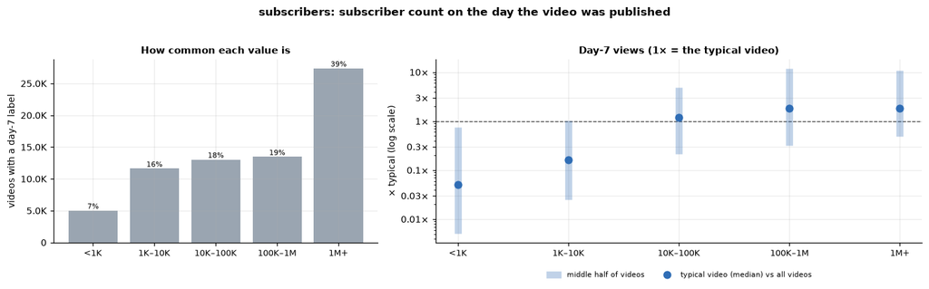

| subscribers | videos | share | median day-7 views | middle half | × typical |
| --- | --- | --- | --- | --- | --- |
| <1K | 5,032 | 7.1% | 60 | 6 – 910 | 0.05× |
| 1K–10K | 11,626 | 16.5% | 195 | 30 – 1.2K | 0.16× |
| 10K–100K | 13,047 | 18.5% | 1.4K | 254 – 5.8K | 1.19× |
| 100K–1M | 13,471 | 19.1% | 2.2K | 383 – 14.4K | 1.81× |
| 1M+ | 27,392 | 38.8% | 2.2K | 579 – 12.8K | 1.83× |

**Source at forecast time:** looked up from the channel. Missing for 31% of videos (channel statistics recorded after publishing are left out). Most common value: **1M+** (39% of videos). Best: **1M+** (2.2K views, 1.83× typical). Worst: **<1K** (60, 0.05×). Explains **22.5%** of the variation in day-7 views.

**What it shows.** The bigger the channel, the more views, up to about 100K subscribers. A channel under 1K subscribers typically gets about 60 views a week; one with 100K or more gets about 2,200. Above 100K the typical video stops rising: 100K to 1M and 1M+ channels are about the same. **Verdict: keep.**

### subscribers at 7, 14, 21 and 30 days

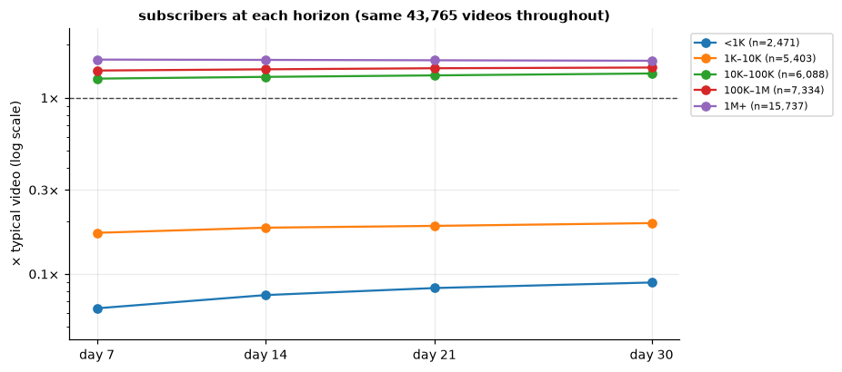

| subscribers | day 7 | day 14 | day 21 | day 30 |
| --- | --- | --- | --- | --- |
| <1K | 0.06× | 0.08× | 0.08× | 0.09× |
| 1K–10K | 0.17× | 0.18× | 0.19× | 0.19× |
| 10K–100K | 1.28× | 1.31× | 1.34× | 1.37× |
| 100K–1M | 1.43× | 1.45× | 1.47× | 1.48× |
| 1M+ | 1.65× | 1.64× | 1.63× | 1.62× |

**Over time.** The pattern is the same at day 7 and day 30. Small channels gain slightly relative to big ones over the month, but the order never changes.

## channel average views per video

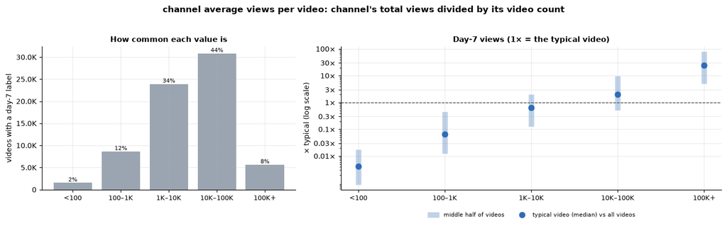

| channel average views per video | videos | share | median day-7 views | middle half | × typical |
| --- | --- | --- | --- | --- | --- |
| <100 | 1,529 | 2.2% | 5 | 1 – 21 | 0.00× |
| 100–1K | 8,635 | 12.2% | 80 | 15 – 546 | 0.07× |
| 1K–10K | 23,915 | 33.9% | 774 | 150 – 2.4K | 0.65× |
| 10K–100K | 30,838 | 43.7% | 2.4K | 626 – 11.8K | 1.98× |
| 100K+ | 5,642 | 8.0% | 29.3K | 6.1K – 97.1K | 24× |

**Source at forecast time:** looked up from the channel. Missing for 31% of videos (channel statistics recorded after publishing are left out). Most common value: **10K–100K** (44% of videos). Best: **100K+** (29.3K views, 24× typical). Worst: **<100** (5, 0.00×). Explains **38.1%** of the variation in day-7 views.

**What it shows.** The single strongest input: 38% of the variation on its own. A channel whose past videos averaged over 100K views typically gets about 29,000 views on a new video; one averaging under 100 gets about 5. It works better than subscribers because it measures how many people actually watch, not how many once subscribed. **Verdict: keep.**

## channel video count

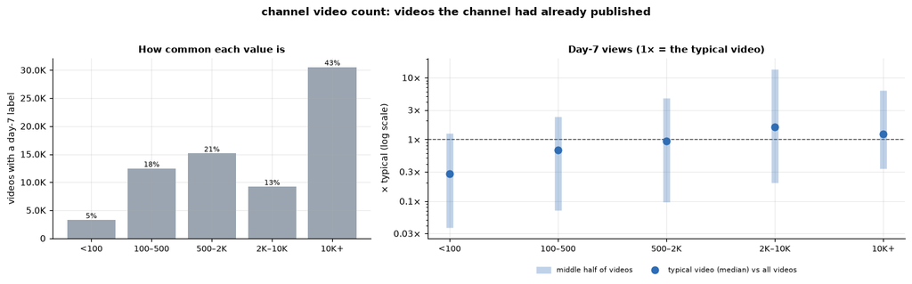

| channel video count | videos | share | median day-7 views | middle half | × typical |
| --- | --- | --- | --- | --- | --- |
| <100 | 3,269 | 4.6% | 337 | 45 – 1.5K | 0.28× |
| 100–500 | 12,439 | 17.6% | 802 | 86 – 2.8K | 0.67× |
| 500–2K | 15,138 | 21.5% | 1.1K | 115 – 5.6K | 0.95× |
| 2K–10K | 9,193 | 13.0% | 1.9K | 239 – 16.3K | 1.58× |
| 10K+ | 30,529 | 43.3% | 1.5K | 408 – 7.4K | 1.24× |

**Source at forecast time:** looked up from the channel. Missing for 31% of videos (channel statistics recorded after publishing are left out). Most common value: **10K+** (43% of videos). Best: **2K–10K** (1.9K views, 1.58× typical). Worst: **<100** (337, 0.28×). Explains **4.5%** of the variation in day-7 views.

**What it shows.** Channels with more uploads get more views, up to about 10,000 videos. Beyond that, views per video fall slightly, because those are the very high-volume channels (mostly news) that split their audience across many clips. **Verdict: keep.**

## channel uploads per day

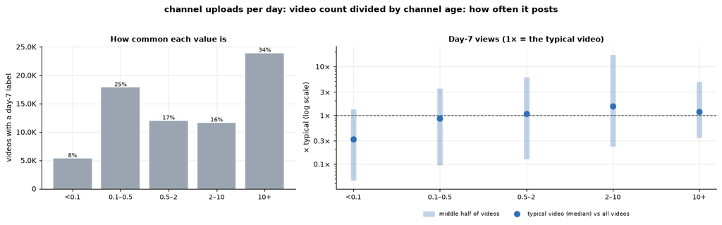

| channel uploads per day | videos | share | median day-7 views | middle half | × typical |
| --- | --- | --- | --- | --- | --- |
| <0.1 | 5,299 | 7.5% | 388 | 56 – 1.6K | 0.32× |
| 0.1–0.5 | 17,823 | 25.3% | 1.1K | 114 – 4.2K | 0.88× |
| 0.5–2 | 11,958 | 16.9% | 1.3K | 152 – 7.3K | 1.08× |
| 2–10 | 11,602 | 16.4% | 1.8K | 276 – 20.7K | 1.54× |
| 10+ | 23,886 | 33.8% | 1.4K | 422 – 5.9K | 1.17× |

**Source at forecast time:** worked out from the channel. Missing for 31% of videos (channel statistics recorded after publishing are left out). Most common value: **10+** (34% of videos). Best: **2–10** (1.8K views, 1.54× typical). Worst: **<0.1** (388, 0.32×). Explains **3.5%** of the variation in day-7 views.

**What it shows.** Channels posting under one video every ten days get the fewest views. Views rise with posting rate up to 2 to 10 videos a day, then drop for channels posting more than 10 a day (again, mostly news). It overlaps heavily with video count (section 15). **Verdict: keep.**

## channel age

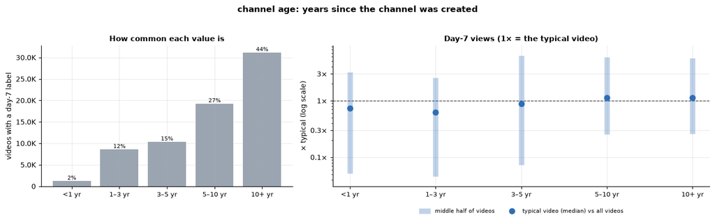

| channel age | videos | share | median day-7 views | middle half | × typical |
| --- | --- | --- | --- | --- | --- |
| <1 yr | 1,215 | 1.7% | 885 | 62 – 3.8K | 0.74× |
| 1–3 yr | 8,583 | 12.2% | 742 | 55 – 3.0K | 0.62× |
| 3–5 yr | 10,348 | 14.7% | 1.1K | 88 – 7.5K | 0.88× |
| 5–10 yr | 19,251 | 27.3% | 1.4K | 307 – 7.1K | 1.13× |
| 10+ yr | 31,171 | 44.2% | 1.3K | 309 – 6.8K | 1.12× |

**Source at forecast time:** looked up from the channel. Missing for 31% of videos (channel statistics recorded after publishing are left out). Most common value: **10+ yr** (44% of videos). Best: **5–10 yr** (1.4K views, 1.13× typical). Worst: **1–3 yr** (742, 0.62×). Explains **2.5%** of the variation in day-7 views.

**What it shows.** A weak effect. Channels older than 5 years get a little more than younger ones, but the difference is under 2×. **Verdict: keep** (it explains 2.5%, over the 1% bar), but it adds little once size is known.

## YouTube topic

[figure not shown]

| YouTube topic | videos | share | median day-7 views | middle half | × typical |
| --- | --- | --- | --- | --- | --- |
| Film | 4,035 | 5.2% | 4.3K | 726 – 40.3K | 3.6× |
| Entertainment | 4,251 | 5.5% | 4.0K | 708 – 22.8K | 3.4× |
| Television program | 4,956 | 6.4% | 3.0K | 1.2K – 17.3K | 2.5× |
| Politics | 11,177 | 14.5% | 1.5K | 315 – 9.0K | 1.25× |
| Society | 19,156 | 24.9% | 1.2K | 285 – 6.0K | 0.98× |
| Lifestyle (sociology) | 9,664 | 12.6% | 1.0K | 108 – 4.4K | 0.87× |
| Music | 2,361 | 3.1% | 906 | 176 – 2.7K | 0.76× |
| other | 15,012 | 19.5% | 842 | 95 – 3.0K | 0.70× |
| Tourism | 2,423 | 3.1% | 570 | 55 – 1.3K | 0.48× |
| Knowledge | 3,914 | 5.1% | 150 | 23 – 1.2K | 0.13× |

**Source at forecast time:** looked up from the channel (not sent yet). Most common value: **Society** (25% of videos). Best: **Film** (4.3K views, 3.6× typical). Worst: **Knowledge** (150, 0.13×). Explains **10.3%** of the variation in day-7 views.

**What it shows.** The topic YouTube assigns to the **channel** (for example Film, Politics, Knowledge). Film and Entertainment channels typically get about 3.5× the typical video; Knowledge channels about 0.13×. It explains 10% on its own.

**Important:** this comes from the channel lookup the API already makes, so it *is* available before publishing. The API does not send it today. **Verdict: keep, and fetch it at forecast time.**

## Inputs where almost every video has the same value

| input | most common value | share of videos | source at forecast time |
| --- | --- | --- | --- |
| channel country | LK | 100.0% | looked up from the channel |

Almost every channel lists Sri Lanka, so country carries no information. **Verdict: drop.**

# 5. Video format

These describe the video itself, and a creator decides them. From here on, the orange diamond (same channel) matters most.

## duration

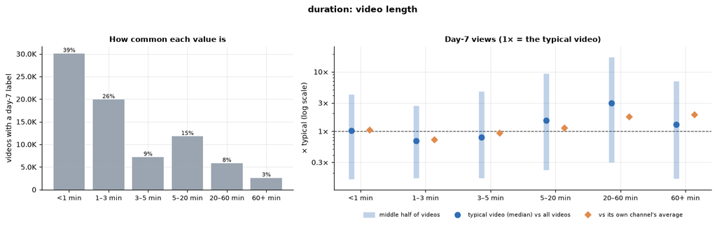

| duration | videos | share | median day-7 views | middle half | × typical | × own channel | videos in own-channel view |
| --- | --- | --- | --- | --- | --- | --- | --- |
| <1 min | 30,109 | 38.9% | 1.2K | 187 – 5.0K | 1.02× | 1.04× | 23,812 |
| 1–3 min | 19,902 | 25.7% | 834 | 197 – 3.3K | 0.70× | 0.72× | 19,594 |
| 3–5 min | 7,186 | 9.3% | 958 | 196 – 5.7K | 0.80× | 0.93× | 6,997 |
| 5–20 min | 11,773 | 15.2% | 1.8K | 268 – 11.3K | 1.52× | 1.14× | 10,767 |
| 20–60 min | 5,832 | 7.5% | 3.6K | 358 – 21.2K | 3.0× | 1.74× | 5,416 |
| 60+ min | 2,597 | 3.4% | 1.6K | 190 – 8.4K | 1.30× | 1.87× | 2,361 |

**Source at forecast time:** on the form. Most common value: **<1 min** (39% of videos). Best: **20–60 min** (3.6K views, 3.0× typical). Worst: **1–3 min** (834, 0.70×). Against its own channel (68,947 videos from the 1,238 channels that use more than one value): best **60+ min** (1.87×), worst **1–3 min** (0.72×): a **2.59×** gap. Largest gap inside one channel-size band: **6.54×** (channels with 1M+ subscribers). Explains **1.6%** of the variation in day-7 views.

**What it shows.** The clearest video-level input. Videos of 20 to 60 minutes get about 3× the typical video, and it holds within the same channel: videos of 20 minutes or more get about 1.7× to 1.9× the channel's average. Videos of **1 to 3 minutes do worst** in both views. Many of them are short news clips, and some are horizontal clips that are not Shorts. **Verdict: keep (strong).**

### duration at 7, 14, 21 and 30 days

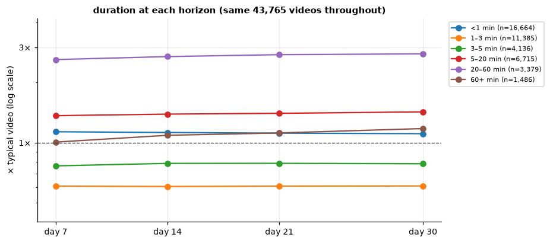

| duration | day 7 | day 14 | day 21 | day 30 |
| --- | --- | --- | --- | --- |
| <1 min | 1.13× | 1.13× | 1.12× | 1.11× |
| 1–3 min | 0.61× | 0.60× | 0.61× | 0.61× |
| 3–5 min | 0.77× | 0.79× | 0.79× | 0.78× |
| 5–20 min | 1.37× | 1.39× | 1.40× | 1.43× |
| 20–60 min | 2.6× | 2.7× | 2.8× | 2.8× |
| 60+ min | 1.01× | 1.09× | 1.12× | 1.18× |

## Short or long-form

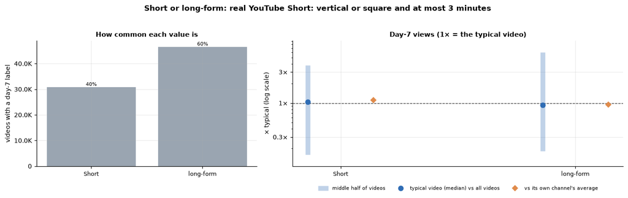

| Short or long-form | videos | share | median day-7 views | middle half | × typical | × own channel | videos in own-channel view |
| --- | --- | --- | --- | --- | --- | --- | --- |
| Short | 30,844 | 39.9% | 1.3K | 192 – 4.5K | 1.05× | 1.10× | 21,628 |
| long-form | 46,555 | 60.1% | 1.1K | 218 – 7.2K | 0.93× | 0.94× | 35,888 |

**Source at forecast time:** not sent yet (form needs the field). Most common value: **long-form** (60% of videos). Best: **Short** (1.3K views, 1.05× typical). Worst: **long-form** (1.1K, 0.93×). Against its own channel (57,516 videos from the 848 channels that use more than one value): best **Short** (1.10×), worst **long-form** (0.94×): a **1.17×** gap. Largest gap inside one channel-size band: **1.97×** (channels with 1K–10K subscribers). Explains **0.1%** of the variation in day-7 views.

**What it shows.** Overall, Shorts and long-form look almost the same (1.3K against 1.1K typical views). Compared with their own channel, Shorts do about 1.17× better. That overall number hides a big split by channel size, shown in the next two charts. **Verdict: keep, and add a Short / long-form field to the form.**

### Short or long-form at 7, 14, 21 and 30 days

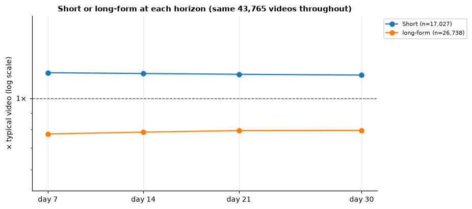

| Short or long-form | day 7 | day 14 | day 21 | day 30 |
| --- | --- | --- | --- | --- |
| Short | 1.20× | 1.19× | 1.19× | 1.18× |
| long-form | 0.77× | 0.78× | 0.79× | 0.79× |

**Over time.** On the same videos, Shorts stay at about 1.2× and long-form at about 0.8× from day 7 to day 30. A Short's advantage does not fade later.

### Shorts against long-form by channel size

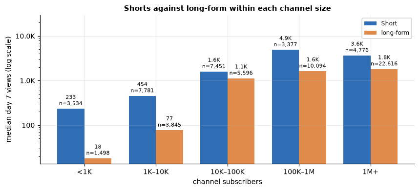

|  | <1K | 1K–10K | 10K–100K | 100K–1M | 1M+ |
| --- | --- | --- | --- | --- | --- |
| all videos in the band (median Short ÷ median long-form) | 13× | 5.9× | 1.41× | 3.0× | 2.0× |
| same channel (Short ÷ long-form, own-channel view) | 1.60× | 1.97× | 1.35× | 0.93× | 0.93× |

**What it shows.** Within every size band, Shorts get more views than long-form: 13× more for channels under 1K subscribers and 6× for 1K to 10K.

The second row compares Shorts with long-form **on the same channel**, which is the fair comparison. For channels under 100K subscribers, Shorts beat the channel's own long-form by about 1.35× to 2×. For channels over 100K, Shorts do slightly worse. So "post Shorts" is good advice for small and mid-size channels, and not for big ones.

## category

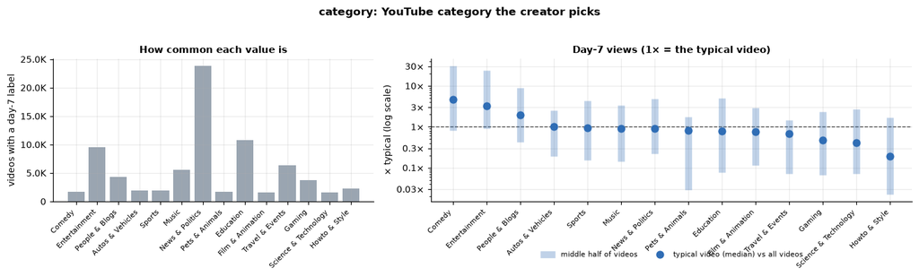

| category | videos | share | median day-7 views | middle half | × typical |
| --- | --- | --- | --- | --- | --- |
| Comedy | 1,735 | 2.3% | 5.6K | 993 – 36.4K | 4.7× |
| Entertainment | 9,582 | 12.5% | 3.9K | 1.1K – 28.9K | 3.3× |
| People & Blogs | 4,296 | 5.6% | 2.3K | 503 – 10.7K | 1.93× |
| Autos & Vehicles | 1,876 | 2.4% | 1.2K | 225 – 3.1K | 1.03× |
| Sports | 1,875 | 2.4% | 1.1K | 186 – 5.3K | 0.94× |
| Music | 5,512 | 7.2% | 1.1K | 171 – 4.1K | 0.92× |
| News & Politics | 23,885 | 31.1% | 1.1K | 265 – 5.8K | 0.89× |
| Pets & Animals | 1,665 | 2.2% | 962 | 34 – 2.1K | 0.80× |
| Education | 10,794 | 14.1% | 926 | 91 – 5.9K | 0.77× |
| Film & Animation | 1,638 | 2.1% | 919 | 138 – 3.5K | 0.77× |
| Travel & Events | 6,337 | 8.2% | 828 | 86 – 1.7K | 0.69× |
| Gaming | 3,772 | 4.9% | 559 | 80 – 2.8K | 0.47× |
| Science & Technology | 1,543 | 2.0% | 494 | 86 – 3.3K | 0.41× |
| Howto & Style | 2,311 | 3.0% | 229 | 27 – 2.0K | 0.19× |

**Source at forecast time:** on the form. Most common value: **News & Politics** (31% of videos). Best: **Comedy** (5.6K views, 4.7× typical). Worst: **Howto & Style** (229, 0.19×). Explains **9.1%** of the variation in day-7 views.

**What it shows.** Comedy (4.7×), Entertainment (3.3×) and People & Blogs (1.9×) get the most views; Howto & Style (0.19×) and Science & Technology (0.41×) the fewest. This raw ranking is partly about which channels post in each category (section 10 shows this). **Verdict: keep.**

### category at 7, 14, 21 and 30 days

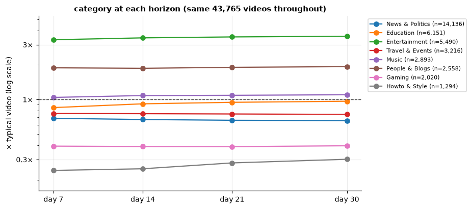

| category | day 7 | day 14 | day 21 | day 30 |
| --- | --- | --- | --- | --- |
| News & Politics | 0.69× | 0.67× | 0.66× | 0.65× |
| Education | 0.85× | 0.92× | 0.94× | 0.97× |
| Entertainment | 3.3× | 3.4× | 3.5× | 3.6× |
| Travel & Events | 0.75× | 0.75× | 0.75× | 0.74× |
| Music | 1.04× | 1.08× | 1.09× | 1.10× |
| People & Blogs | 1.89× | 1.87× | 1.91× | 1.93× |
| Gaming | 0.39× | 0.39× | 0.39× | 0.40× |
| Howto & Style | 0.24× | 0.25× | 0.28× | 0.30× |

**Over time.** Mostly stable. Education and Howto & Style gain relative to others after the first week (people search for them later), while News & Politics loses a little (news is watched on the day).

## Inputs where almost every video has the same value

| input | most common value | share of videos | source at forecast time |
| --- | --- | --- | --- |
| HD or SD | HD | 96.1% | not on the form |
| captions | false | 99.8% | not on the form |
| made for kids | false | 99.5% | not on the form |

HD or SD, captions and made for kids are the same for 96% or more of videos, and are not on the form. **Verdict: drop all three.**

# 6. Language

Language inputs vary within a channel more than you might expect: about a third of channels post in more than one audio language.

## audio language

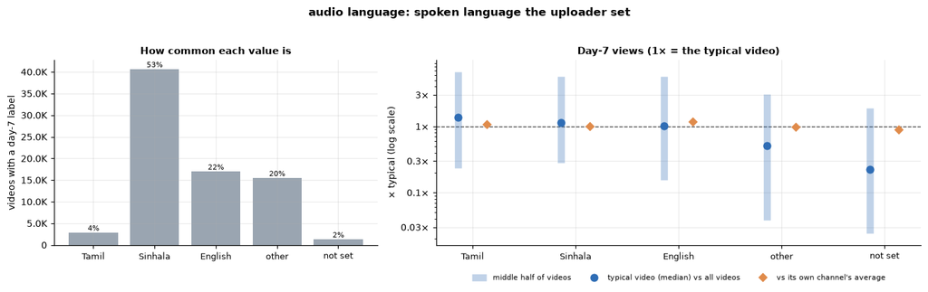

| audio language | videos | share | median day-7 views | middle half | × typical | × own channel | videos in own-channel view |
| --- | --- | --- | --- | --- | --- | --- | --- |
| Tamil | 2,895 | 3.7% | 1.6K | 284 – 8.0K | 1.37× | 1.07× | 569 |
| Sinhala | 40,671 | 52.5% | 1.4K | 339 – 6.8K | 1.15× | 1.00× | 3,911 |
| English | 16,997 | 22.0% | 1.2K | 186 – 6.8K | 1.02× | 1.16× | 3,130 |
| other | 15,504 | 20.0% | 617 | 46 – 3.7K | 0.52× | 0.97× | 11,981 |
| not set | 1,332 | 1.7% | 268 | 29 – 2.3K | 0.22× | 0.88× | 1,281 |

**Source at forecast time:** on the form. Most common value: **Sinhala** (53% of videos). Best: **Tamil** (1.6K views, 1.37× typical). Worst: **not set** (268, 0.22×). Against its own channel (20,872 videos from the 545 channels that use more than one value): best **English** (1.16×), worst **not set** (0.88×): a **1.32×** gap. Largest gap inside one channel-size band: **1.66×** (channels with 1K–10K subscribers). Explains **3.4%** of the variation in day-7 views.

**What it shows.** Tamil (1.4×) and Sinhala (1.15×) videos get more views than English (1.0×). Videos with no audio language set do worst (0.22×), probably because careful uploaders set it. Within the same channel, English videos do a little better than the channel's other languages. **Verdict: keep.**

## default language

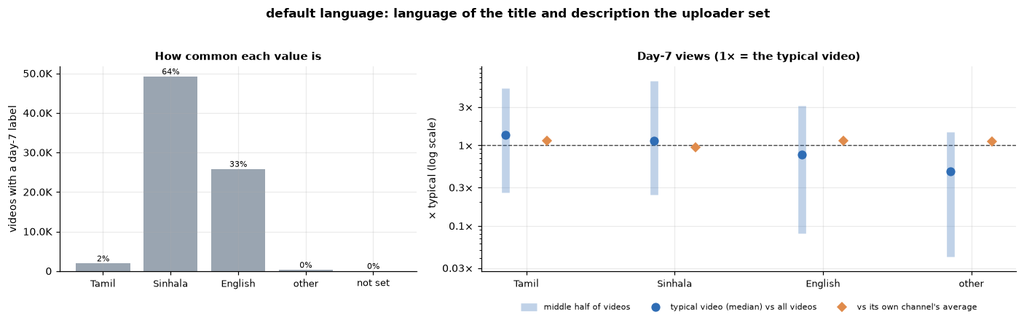

| default language | videos | share | median day-7 views | middle half | × typical | × own channel | videos in own-channel view |
| --- | --- | --- | --- | --- | --- | --- | --- |
| Tamil | 1,934 | 2.5% | 1.6K | 310 – 6.2K | 1.35× | 1.13× | 809 |
| Sinhala | 49,267 | 63.7% | 1.4K | 292 – 7.6K | 1.14× | 0.95× | 23,608 |
| English | 25,856 | 33.4% | 926 | 96 – 3.7K | 0.77× | 1.13× | 9,556 |
| other | 315 | 0.4% | 567 | 50 – 1.8K | 0.47× | 1.11× | 219 |
| not set | 27 | 0.0% | 135 | 46 – 490 | 0.11× |  | 24 |

**Source at forecast time:** on the form (mapped from audio language). Most common value: **Sinhala** (64% of videos). Best: **Tamil** (1.6K views, 1.35× typical). Worst: **other** (567, 0.47×). Against its own channel (34,216 videos from the 582 channels that use more than one value): best **English** (1.13×), worst **Sinhala** (0.95×): a **1.20×** gap. Largest gap inside one channel-size band: **1.82×** (channels with 100K–1M subscribers). Explains **1.9%** of the variation in day-7 views.

**What it shows.** Similar to audio language, and they agree on only 58% of videos. The API sends audio language mapped to en / si / ta, so the model should be trained on that same mapping (section 16). **Verdict: keep one; audio language is the one the form collects.**

## title script

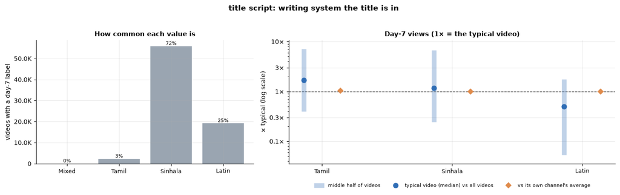

| title script | videos | share | median day-7 views | middle half | × typical | × own channel | videos in own-channel view |
| --- | --- | --- | --- | --- | --- | --- | --- |
| Mixed | 23 | 0.0% | 7.3K | 4.7K – 11.1K | 6.1× |  | 21 |
| Tamil | 2,272 | 2.9% | 2.0K | 480 – 8.5K | 1.68× | 1.03× | 1,338 |
| Sinhala | 55,922 | 72.3% | 1.4K | 292 – 8.1K | 1.18× | 1.00× | 41,362 |
| Latin | 19,182 | 24.8% | 599 | 64 – 2.1K | 0.50× | 0.98× | 11,017 |

**Source at forecast time:** worked out from the title (not sent yet). Most common value: **Sinhala** (72% of videos). Best: **Tamil** (2.0K views, 1.68× typical). Worst: **Latin** (599, 0.50×). Against its own channel (53,738 videos from the 805 channels that use more than one value): best **Tamil** (1.03×), worst **Latin** (0.98×): a **1.05×** gap. Largest gap inside one channel-size band: **1.64×** (channels with 1M+ subscribers). Explains **4.0%** of the variation in day-7 views.

**What it shows.** Titles in Tamil script (1.7×) and Sinhala script (1.2×) do better than Latin-script titles (0.5×). Within a channel the difference almost disappears (1.05×): the raw gap is mostly which channels write in which script. It passes the rule only through the biggest channels. **Verdict: keep, weak. It is worked out from the title, which the form already collects.**

# 7. Publish timing

All times are Sri Lanka time.

## publish hour

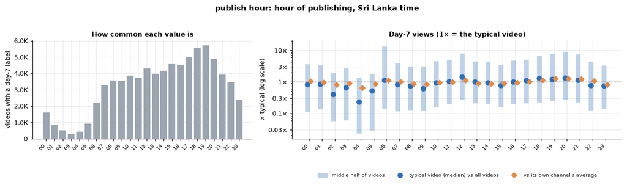

| publish hour | videos | share | median day-7 views | middle half | × typical | × own channel | videos in own-channel view |
| --- | --- | --- | --- | --- | --- | --- | --- |
| 00 | 1,610 | 2.1% | 1000 | 132 – 4.3K | 0.84× | 1.05× | 1,524 |
| 01 | 869 | 1.1% | 1.0K | 166 – 4.1K | 0.86× | 0.93× | 855 |
| 02 | 530 | 0.7% | 490 | 68 – 2.3K | 0.41× | 0.80× | 501 |
| 03 | 310 | 0.4% | 794 | 73 – 3.3K | 0.66× | 0.87× | 299 |
| 04 | 436 | 0.6% | 278 | 28 – 1.7K | 0.23× | 0.64× | 404 |
| 05 | 931 | 1.2% | 628 | 35 – 2.2K | 0.52× | 0.84× | 903 |
| 06 | 2,194 | 2.8% | 1.4K | 169 – 16.4K | 1.13× | 1.10× | 2,141 |
| 07 | 3,308 | 4.3% | 1.0K | 142 – 4.7K | 0.84× | 1.00× | 3,240 |
| 08 | 3,569 | 4.6% | 906 | 156 – 3.7K | 0.76× | 0.85× | 3,450 |
| 09 | 3,538 | 4.6% | 732 | 147 – 3.8K | 0.61× | 0.83× | 3,472 |
| 10 | 3,865 | 5.0% | 1.1K | 190 – 5.6K | 0.94× | 0.94× | 3,770 |
| 11 | 3,740 | 4.8% | 1.2K | 239 – 6.0K | 1.03× | 0.98× | 3,649 |
| 12 | 4,299 | 5.6% | 1.7K | 332 – 9.6K | 1.44× | 1.10× | 4,158 |
| 13 | 3,969 | 5.1% | 1.2K | 255 – 5.3K | 1.00× | 0.87× | 3,879 |
| 14 | 4,162 | 5.4% | 1.1K | 247 – 5.2K | 0.93× | 0.86× | 4,115 |
| 15 | 4,579 | 5.9% | 940 | 186 – 4.1K | 0.79× | 0.89× | 4,435 |
| 16 | 4,511 | 5.8% | 1.2K | 236 – 5.7K | 1.00× | 0.95× | 4,311 |
| 17 | 5,014 | 6.5% | 1.3K | 250 – 6.1K | 1.12× | 1.01× | 4,749 |
| 18 | 5,583 | 7.2% | 1.6K | 268 – 8.2K | 1.30× | 1.12× | 5,203 |
| 19 | 5,726 | 7.4% | 1.5K | 292 – 9.3K | 1.23× | 1.25× | 5,348 |
| 20 | 4,914 | 6.3% | 1.6K | 325 – 11.0K | 1.33× | 1.24× | 4,741 |
| 21 | 3,916 | 5.1% | 1.4K | 267 – 8.9K | 1.16× | 1.20× | 3,829 |
| 22 | 3,467 | 4.5% | 928 | 151 – 5.4K | 0.78× | 1.07× | 3,408 |
| 23 | 2,359 | 3.0% | 895 | 169 – 4.0K | 0.75× | 0.81× | 2,309 |

**Source at forecast time:** on the form (optional). Most common value: **19** (7% of videos). Best: **12** (1.7K views, 1.44× typical). Worst: **04** (278, 0.23×). Against its own channel (74,693 videos from the 1,442 channels that use more than one value): best **19** (1.25×), worst **04** (0.64×): a **1.94×** gap. Largest gap inside one channel-size band: **2.95×** (channels with 1M+ subscribers). Explains **1.7%** of the variation in day-7 views.

## publish time band

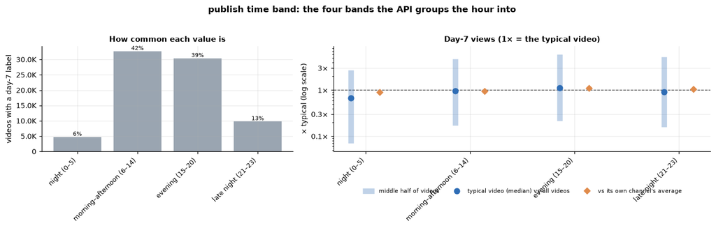

| publish time band | videos | share | median day-7 views | middle half | × typical | × own channel | videos in own-channel view |
| --- | --- | --- | --- | --- | --- | --- | --- |
| night (0–5) | 4,686 | 6.1% | 814 | 84 – 3.2K | 0.68× | 0.90× | 4,291 |
| morning–afternoon (6–14) | 32,644 | 42.2% | 1.1K | 204 – 5.7K | 0.95× | 0.94× | 31,683 |
| evening (15–20) | 30,327 | 39.2% | 1.3K | 255 – 7.1K | 1.12× | 1.08× | 27,394 |
| late night (21–23) | 9,742 | 12.6% | 1.1K | 191 – 6.3K | 0.92× | 1.05× | 9,514 |

**Source at forecast time:** on the form (optional). Most common value: **morning–afternoon (6–14)** (42% of videos). Best: **evening (15–20)** (1.3K views, 1.12× typical). Worst: **night (0–5)** (814, 0.68×). Against its own channel (72,882 videos from the 1,312 channels that use more than one value): best **evening (15–20)** (1.08×), worst **night (0–5)** (0.90×): a **1.20×** gap. Largest gap inside one channel-size band: **1.46×** (channels with 1M+ subscribers). Explains **0.6%** of the variation in day-7 views.

**What it shows.** The API groups the hour into four bands. Grouping loses most of the difference: evening is best, but the four bands are within 1.2× of each other. **Verdict: keep, but sending the exact hour would keep more information than the band.**

## publish weekday

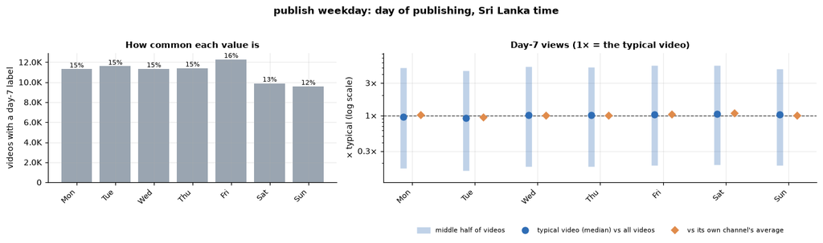

| publish weekday | videos | share | median day-7 views | middle half | × typical | × own channel | videos in own-channel view |
| --- | --- | --- | --- | --- | --- | --- | --- |
| Mon | 11,309 | 14.6% | 1.1K | 199 – 6.0K | 0.95× | 1.00× | 11,104 |
| Tue | 11,592 | 15.0% | 1.1K | 187 – 5.4K | 0.92× | 0.93× | 11,358 |
| Wed | 11,339 | 14.7% | 1.2K | 214 – 6.2K | 1.01× | 0.98× | 11,098 |
| Thu | 11,407 | 14.7% | 1.2K | 212 – 6.1K | 1.00× | 1.00× | 11,143 |
| Fri | 12,275 | 15.9% | 1.2K | 220 – 6.5K | 1.03× | 1.04× | 11,985 |
| Sat | 9,895 | 12.8% | 1.3K | 227 – 6.5K | 1.06× | 1.06× | 9,631 |
| Sun | 9,582 | 12.4% | 1.2K | 220 – 5.8K | 1.02× | 1.00× | 9,319 |

**Source at forecast time:** on the form (optional). Most common value: **Fri** (16% of videos). Best: **Sat** (1.3K views, 1.06× typical). Worst: **Tue** (1.1K, 0.92×). Against its own channel (75,638 videos from the 1,512 channels that use more than one value): best **Sat** (1.06×), worst **Tue** (0.93×): a **1.15×** gap. Largest gap inside one channel-size band: **1.31×** (channels with <1K subscribers). Explains **0.1%** of the variation in day-7 views.

**What it shows.** Views are almost the same on every day (0.92× to 1.06×). It passes the rule only for the smallest channels. **Verdict: keep, weak.**

## weekend

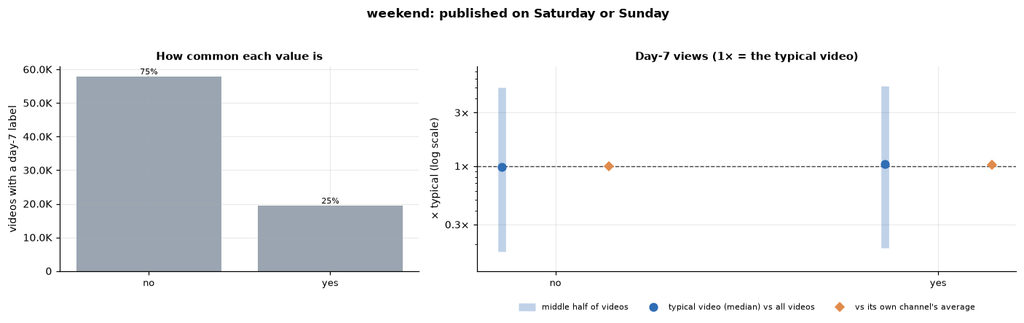

| weekend | videos | share | median day-7 views | middle half | × typical | × own channel | videos in own-channel view |
| --- | --- | --- | --- | --- | --- | --- | --- |
| no | 57,922 | 74.8% | 1.2K | 207 – 6.0K | 0.99× | 0.99× | 55,139 |
| yes | 19,477 | 25.2% | 1.2K | 223 – 6.2K | 1.04× | 1.03× | 18,916 |

**Source at forecast time:** on the form (optional). Most common value: **no** (75% of videos). Best: **yes** (1.2K views, 1.04× typical). Worst: **no** (1.2K, 0.99×). Against its own channel (74,055 videos from the 1,383 channels that use more than one value): best **yes** (1.03×), worst **no** (0.99×): a **1.04×** gap. Largest gap inside one channel-size band: **1.07×** (channels with <1K subscribers). Explains **0.0%** of the variation in day-7 views.

**What it shows.** No difference (1.04×). **Verdict: drop.** The weekday carries anything weekend could, and neither matters much.

# 8. Title

The title is typed on the form but is not used by the forecast today (only for tone advice). These inputs could be worked out from it for free.

## title length

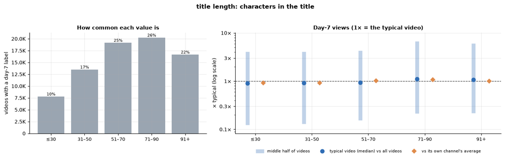

| title length | videos | share | median day-7 views | middle half | × typical | × own channel | videos in own-channel view |
| --- | --- | --- | --- | --- | --- | --- | --- |
| ≤30 | 7,810 | 10.1% | 1.1K | 148 – 4.9K | 0.91× | 0.91× | 7,273 |
| 31–50 | 13,509 | 17.5% | 1.1K | 156 – 4.9K | 0.92× | 0.92× | 13,113 |
| 51–70 | 19,160 | 24.8% | 1.1K | 185 – 5.1K | 0.93× | 1.02× | 18,692 |
| 71–90 | 20,252 | 26.2% | 1.3K | 258 – 8.0K | 1.12× | 1.08× | 19,644 |
| 91+ | 16,668 | 21.5% | 1.3K | 259 – 7.3K | 1.07× | 1.00× | 15,358 |

**Source at forecast time:** worked out from the title (not sent yet). Most common value: **71–90** (26% of videos). Best: **71–90** (1.3K views, 1.12× typical). Worst: **≤30** (1.1K, 0.91×). Against its own channel (74,080 videos from the 1,443 channels that use more than one value): best **71–90** (1.08×), worst **≤30** (0.91×): a **1.18×** gap. Largest gap inside one channel-size band: **1.53×** (channels with 1M+ subscribers). Explains **0.6%** of the variation in day-7 views.

**What it shows.** Longer titles (over 70 characters) get slightly more views, raw and within a channel (1.18× gap). **Verdict: keep, weak.** It repeats word count (section 15), so one of the two is enough.

## title word count

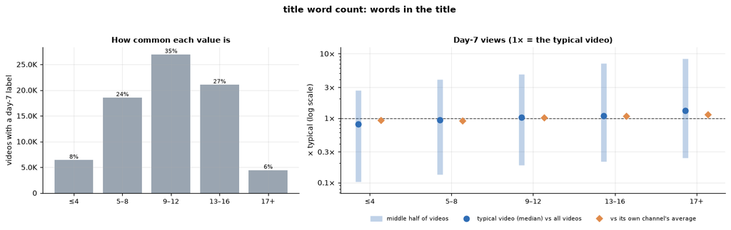

| title word count | videos | share | median day-7 views | middle half | × typical | × own channel | videos in own-channel view |
| --- | --- | --- | --- | --- | --- | --- | --- |
| ≤4 | 6,396 | 8.3% | 975 | 124 – 3.3K | 0.81× | 0.92× | 6,008 |
| 5–8 | 18,551 | 24.0% | 1.1K | 160 – 4.7K | 0.94× | 0.90× | 17,783 |
| 9–12 | 26,959 | 34.8% | 1.2K | 222 – 5.8K | 1.02× | 1.01× | 26,219 |
| 13–16 | 21,047 | 27.2% | 1.3K | 252 – 8.5K | 1.09× | 1.08× | 20,359 |
| 17+ | 4,446 | 5.7% | 1.6K | 292 – 10.0K | 1.32× | 1.14× | 4,223 |

**Source at forecast time:** worked out from the title (not sent yet). Most common value: **9–12** (35% of videos). Best: **17+** (1.6K views, 1.32× typical). Worst: **≤4** (975, 0.81×). Against its own channel (74,592 videos from the 1,460 channels that use more than one value): best **17+** (1.14×), worst **5–8** (0.90×): a **1.27×** gap. Largest gap inside one channel-size band: **2.00×** (channels with 1M+ subscribers). Explains **0.8%** of the variation in day-7 views.

**What it shows.** The same pattern as title length, a little clearer (1.27× within a channel). **Verdict: keep instead of title length.**

## number in title

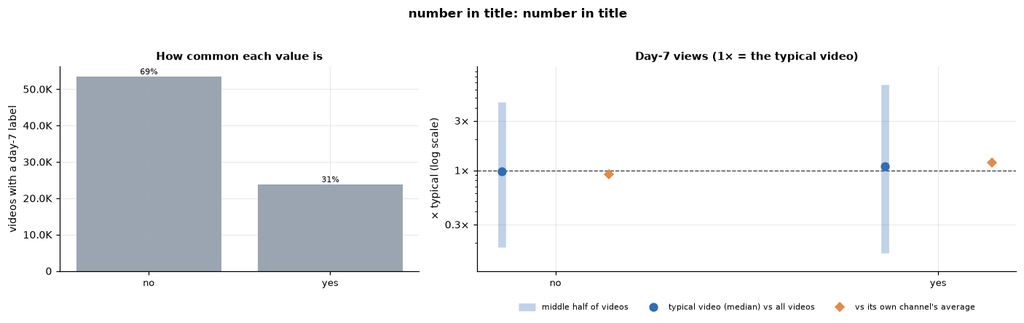

| number in title | videos | share | median day-7 views | middle half | × typical | × own channel | videos in own-channel view |
| --- | --- | --- | --- | --- | --- | --- | --- |
| no | 53,525 | 69.2% | 1.2K | 219 – 5.4K | 0.97× | 0.92× | 45,873 |
| yes | 23,874 | 30.8% | 1.3K | 192 – 8.0K | 1.09× | 1.19× | 21,021 |

**Source at forecast time:** worked out from the title (not sent yet). Most common value: **no** (69% of videos). Best: **yes** (1.3K views, 1.09× typical). Worst: **no** (1.2K, 0.97×). Against its own channel (66,894 videos from the 1,098 channels that use more than one value): best **yes** (1.19×), worst **no** (0.92×): a **1.29×** gap. Largest gap inside one channel-size band: **1.79×** (channels with 1M+ subscribers). Explains **0.0%** of the variation in day-7 views.

**What it shows.** No difference raw, but within the same channel, titles with a number get about 1.3× those without. Numbers often mark episodes or lists. **Verdict: keep (moderate).**

## question mark in title

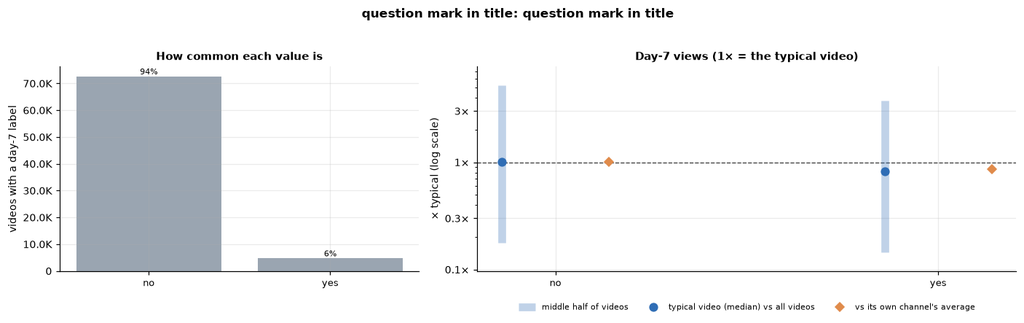

| question mark in title | videos | share | median day-7 views | middle half | × typical | × own channel | videos in own-channel view |
| --- | --- | --- | --- | --- | --- | --- | --- |
| no | 72,663 | 93.9% | 1.2K | 213 – 6.2K | 1.01× | 1.01× | 51,381 |
| yes | 4,736 | 6.1% | 985 | 174 – 4.5K | 0.82× | 0.86× | 4,615 |

**Source at forecast time:** worked out from the title (not sent yet). Most common value: **no** (94% of videos). Best: **no** (1.2K views, 1.01× typical). Worst: **yes** (985, 0.82×). Against its own channel (55,996 videos from the 648 channels that use more than one value): best **no** (1.01×), worst **yes** (0.86×): a **1.18×** gap. Largest gap inside one channel-size band: **1.38×** (channels with 1M+ subscribers). Explains **0.0%** of the variation in day-7 views.

**What it shows.** Only 6% of titles have one, and they do slightly worse. **Verdict: keep, weak.**

## exclamation mark in title

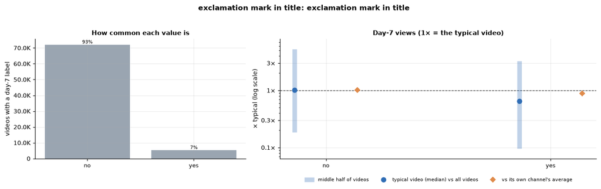

| exclamation mark in title | videos | share | median day-7 views | middle half | × typical | × own channel | videos in own-channel view |
| --- | --- | --- | --- | --- | --- | --- | --- |
| no | 72,070 | 93.1% | 1.2K | 222 – 6.3K | 1.02× | 1.01× | 45,958 |
| yes | 5,329 | 6.9% | 771 | 115 – 3.9K | 0.64× | 0.89× | 5,078 |

**Source at forecast time:** worked out from the title (not sent yet). Most common value: **no** (93% of videos). Best: **no** (1.2K views, 1.02× typical). Worst: **yes** (771, 0.64×). Against its own channel (51,036 videos from the 601 channels that use more than one value): best **no** (1.01×), worst **yes** (0.89×): a **1.14×** gap. Largest gap inside one channel-size band: **1.47×** (channels with 1M+ subscribers). Explains **0.4%** of the variation in day-7 views.

**What it shows.** Only 7% of titles have one. They look much worse raw (0.64×) but only slightly worse within a channel: the channels that use them are smaller. **Verdict: keep, weak.**

## capital letters in title

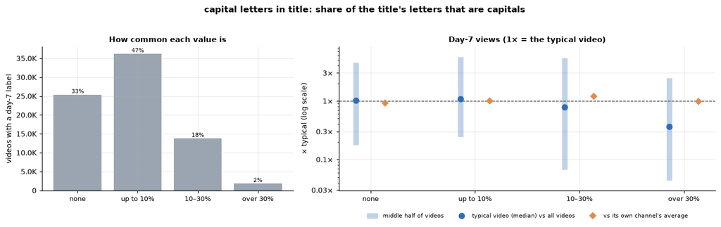

| capital letters in title | videos | share | median day-7 views | middle half | × typical | × own channel | videos in own-channel view |
| --- | --- | --- | --- | --- | --- | --- | --- |
| none | 25,412 | 32.8% | 1.2K | 213 – 5.4K | 1.01× | 0.91× | 23,641 |
| up to 10% | 36,246 | 46.8% | 1.3K | 289 – 6.7K | 1.08× | 1.00× | 32,609 |
| 10–30% | 13,843 | 17.9% | 942 | 80 – 6.5K | 0.79× | 1.20× | 12,616 |
| over 30% | 1,898 | 2.5% | 437 | 53 – 3.0K | 0.37× | 0.97× | 1,755 |

**Source at forecast time:** worked out from the title (not sent yet). Most common value: **up to 10%** (47% of videos). Best: **up to 10%** (1.3K views, 1.08× typical). Worst: **over 30%** (437, 0.37×). Against its own channel (70,621 videos from the 1,277 channels that use more than one value): best **10–30%** (1.20×), worst **none** (0.91×): a **1.31×** gap. Largest gap inside one channel-size band: **2.72×** (channels with 1M+ subscribers). Explains **1.2%** of the variation in day-7 views.

**What it shows.** Raw, titles with over 30% capitals do badly (0.37×). Within the same channel, a moderate amount (10 to 30%) is best and none is worst (1.31× gap). **Verdict: keep (moderate).** Shouting titles belong to smaller channels; a few capitals help.

# 9. Tags and description

Neither is on the form today, so using them would need two new form fields.

## tag count

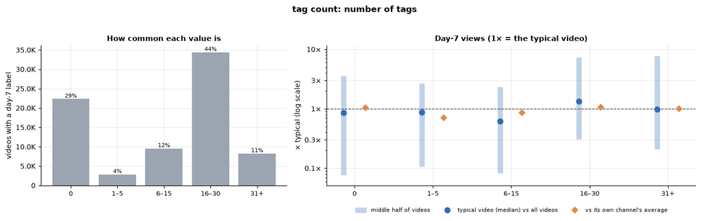

| tag count | videos | share | median day-7 views | middle half | × typical | × own channel | videos in own-channel view |
| --- | --- | --- | --- | --- | --- | --- | --- |
| 0 | 22,341 | 28.9% | 1.0K | 92 – 4.3K | 0.85× | 1.04× | 9,252 |
| 1–5 | 2,858 | 3.7% | 1.0K | 126 – 3.2K | 0.87× | 0.71× | 2,352 |
| 6–15 | 9,545 | 12.3% | 736 | 99 – 2.8K | 0.61× | 0.86× | 7,648 |
| 16–30 | 34,415 | 44.5% | 1.6K | 366 – 8.7K | 1.33× | 1.07× | 23,444 |
| 31+ | 8,240 | 10.6% | 1.2K | 249 – 9.2K | 0.98× | 1.01× | 6,859 |

**Source at forecast time:** not on the form. Most common value: **16–30** (44% of videos). Best: **16–30** (1.6K views, 1.33× typical). Worst: **6–15** (736, 0.61×). Against its own channel (49,555 videos from the 848 channels that use more than one value): best **16–30** (1.07×), worst **1–5** (0.71×): a **1.50×** gap. Largest gap inside one channel-size band: **1.56×** (channels with 1M+ subscribers). Explains **3.0%** of the variation in day-7 views.

**What it shows.** 16 to 30 tags is best raw (1.33×). Within a channel, videos with 1 to 5 tags do worst (0.71×) and 16 to 30 best, a 1.5× gap. It explains 3% on its own, more than any title input. **Verdict: keep; needs a form field.**

## description length

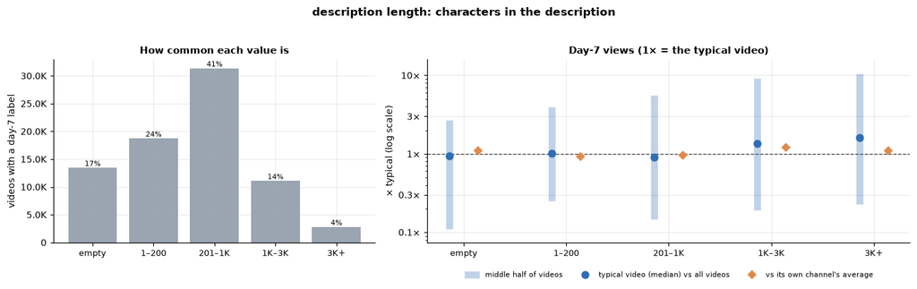

| description length | videos | share | median day-7 views | middle half | × typical | × own channel | videos in own-channel view |
| --- | --- | --- | --- | --- | --- | --- | --- |
| empty | 13,443 | 17.4% | 1.1K | 133 – 3.2K | 0.94× | 1.09× | 7,582 |
| 1–200 | 18,727 | 24.2% | 1.2K | 303 – 4.7K | 1.02× | 0.92× | 16,896 |
| 201–1K | 31,350 | 40.5% | 1.1K | 174 – 6.6K | 0.91× | 0.96× | 20,698 |
| 1K–3K | 11,078 | 14.3% | 1.6K | 229 – 10.9K | 1.34× | 1.20× | 8,354 |
| 3K+ | 2,801 | 3.6% | 1.9K | 272 – 12.7K | 1.62× | 1.10× | 1,870 |

**Source at forecast time:** not on the form. Most common value: **201–1K** (41% of videos). Best: **3K+** (1.9K views, 1.62× typical). Worst: **201–1K** (1.1K, 0.91×). Against its own channel (55,400 videos from the 1,021 channels that use more than one value): best **1K–3K** (1.20×), worst **1–200** (0.92×): a **1.30×** gap. Largest gap inside one channel-size band: **1.65×** (channels with 1M+ subscribers). Explains **0.7%** of the variation in day-7 views.

**What it shows.** Long descriptions (over 1,000 characters) get more views, raw and within a channel (1.3× gap). **Verdict: keep; needs a form field.**

# 10. Category by category

Category changes what works. This section looks at each category separately, using day-7 views. Categories with fewer than 1,000 labelled videos are grouped as "Other".

|  | videos | channels | median day-7 views | % Shorts | median length (min) | median channel subscribers | median channel uploads per day | videos per channel |
| --- | --- | --- | --- | --- | --- | --- | --- | --- |
| Comedy | 1,735 | 73 | 5.6K | 83% | 0.4 | 41.9K | 0.7 | 24 |
| Entertainment | 9,582 | 152 | 3.9K | 31% | 1.9 | 3.3M | 6.5 | 63 |
| People & Blogs | 4,296 | 156 | 2.3K | 28% | 2.2 | 3.1M | 2.3 | 28 |
| Autos & Vehicles | 1,876 | 103 | 1.2K | 73% | 0.4 | 8.9K | 0.5 | 18 |
| Sports | 1,875 | 72 | 1.1K | 37% | 2.8 | 43.2K | 0.6 | 26 |
| Music | 5,512 | 351 | 1.1K | 69% | 1.0 | 22.7K | 0.3 | 16 |
| News & Politics | 23,885 | 57 | 1.1K | 8% | 2.2 | 3.8M | 42.3 | 419 |
| Pets & Animals | 1,665 | 73 | 962 | 89% | 0.3 | 4.3K | 0.5 | 23 |
| Education | 10,794 | 524 | 926 | 54% | 1.4 | 45.1K | 0.4 | 21 |
| Film & Animation | 1,638 | 138 | 919 | 52% | 1.1 | 25.4K | 0.2 | 12 |
| Travel & Events | 6,337 | 372 | 828 | 81% | 0.5 | 3.8K | 0.3 | 17 |
| Gaming | 3,772 | 195 | 559 | 48% | 2.8 | 7.1K | 0.4 | 19 |
| Science & Technology | 1,543 | 138 | 494 | 50% | 1.5 | 38.6K | 0.3 | 11 |
| Howto & Style | 2,311 | 137 | 229 | 74% | 0.6 | 7.0K | 0.3 | 17 |
| Other | 578 | 24 | 63 | 15% | 16.2 | 7.4K | 0.7 | 24 |

**What this shows.** Categories differ in *who* posts, not just in content.

- **News & Politics** is 31% of videos but only 57 channels: about 420 labelled videos each, from channels posting about 42 videos a day with a median of 3.8M subscribers. Only 8% are Shorts.
- **Comedy, Pets & Animals, Travel & Events and Autos & Vehicles** are mostly Shorts (73 to 89%) from small and mid-size channels.
- **Entertainment and People & Blogs** come from very large channels (over 3M subscribers typical), which is much of why they rank high.

## Is News & Politics skewing the results?

News & Politics is 31% of the labelled videos but comes from only about 60 channels, many posting dozens of clips a day. If it behaves differently from everything else, it could be pulling the whole-dataset results in sections 4 to 9. This table repeats every input's day-7 result without it.

| input | explains, all | explains, without News | best value, all | best value, without News | own-channel gap, all | own-channel gap, without News | what News changes |
| --- | --- | --- | --- | --- | --- | --- | --- |
| subscribers | 22.5% | 33.6% | 1M+ | 1M+ |  |  | strength changes |
| channel video count | 4.5% | 8.9% | 2K–10K | 10K+ |  |  | best value changes, strength changes |
| channel age | 2.5% | 3.5% | 5–10 yr | 10+ yr |  |  | best value changes, strength changes |
| channel average views per video | 38.1% | 43.3% | 100K+ | 100K+ |  |  | nothing much |
| channel uploads per day | 3.5% | 5.8% | 2–10 | 10+ |  |  | best value changes, strength changes |
| duration | 1.6% | 1.0% | 20–60 min | 20–60 min | 2.59× | 2.28× | strength changes, own-channel gap changes |
| Short or long-form | 0.1% | 0.2% | Short | long-form | 1.17× | 1.08× | best value changes |
| audio language | 3.4% | 4.3% | Tamil | Sinhala | 1.32× | 1.27× | best value changes |
| default language | 1.9% | 3.1% | Tamil | Tamil | 1.20× | 1.22× | strength changes |
| title script | 4.0% | 6.1% | Tamil | Tamil | 1.05× | 1.07× | strength changes |
| publish hour | 1.7% | 1.5% | 12 | 21 | 1.94× | 1.62× | best value changes, own-channel gap changes |
| publish time band | 0.6% | 0.7% | evening (15–20) | evening (15–20) | 1.20× | 1.21× | nothing much |
| publish weekday | 0.1% | 0.1% | Sat | Fri | 1.15× | 1.09× | best value changes |
| weekend | 0.0% | 0.0% | yes | yes | 1.04× | 1.01× | nothing much |
| title length | 0.6% | 0.6% | 71–90 | 71–90 | 1.18× | 1.17× | nothing much |
| title word count | 0.8% | 0.7% | 17+ | 17+ | 1.27× | 1.18× | nothing much |
| number in title | 0.0% | 0.1% | yes | no | 1.29× | 1.27× | best value changes |
| question mark in title | 0.0% | 0.0% | no | no | 1.18× | 1.14× | nothing much |
| exclamation mark in title | 0.4% | 0.4% | no | no | 1.14× | 1.13× | nothing much |
| capital letters in title | 1.2% | 3.0% | up to 10% | none | 1.31× | 1.10× | best value changes, strength changes, own-chan... |
| tag count | 3.0% | 3.2% | 16–30 | 31+ | 1.50× | 1.66× | best value changes, own-channel gap changes |
| description length | 0.7% | 0.5% | 3K+ | 3K+ | 1.30× | 1.19× | own-channel gap changes |
| YouTube topic | 10.3% | 14.4% | Film | Film |  |  | strength changes |

**What this shows.** Yes, News & Politics pulls several results, in three ways.

- **It hides how much channel size matters.** Without News, subscribers explain 34% instead of 23%, channel video count 9% instead of 4.5%, and topic 14% instead of 10%. News channels are huge but get few views per clip, which breaks the "bigger channel, more views" pattern for everyone else.
- **It inflates some video-level effects.** News's rare Shorts, capitalised titles and long descriptions do very well against their own channel, so with News removed the own-channel gap falls for Shorts (1.17× to 1.08×), capital letters (1.31× to 1.10×), description length (1.30× to 1.19×) and publish hour (1.94× to 1.62×). Without News the best publish hour moves from 12:00 to 21:00.
- **Raw best values flip for a few inputs:** Short or long-form (Shorts best with News, long-form best without), number in title and publish weekday.

The Shorts finding by channel size also holds without News, and gets sharper. Compared with their own long-form, Shorts are 2.0× for channels under 1K subscribers and 1.4× to 1.9× up to 100K; for 1M+ channels outside News they are 0.43×.

**So:** results for one input over the whole dataset should be read with News in mind. The per-category pages below remove the problem, because each one only compares videos within the same category.